# PML: Prediction Assignment Writeup

James Ashdown

8 March 2020

## Read in the data

```r
traindat = read.csv("pml-training.csv")
testdat = read.csv("pml-testing.csv")
```

## Set the seed and view the data

```r
set.seed(3000)
library(caret)
library(randomForest)
library(e1071)
library(gbm)
library(rpart)
dim(traindat)
```

```
## [1] 19622   160
```

```r
dim(testdat)
```

```
## [1]  20 160
```

```r
head(traindat)
```

```
##   X user_name raw_timestamp_part_1 raw_timestamp_part_2   cvtd_timestamp
## 1 1  carlitos           1323084231               788290 05/12/2011 11:23
## 2 2  carlitos           1323084231               808298 05/12/2011 11:23
## 3 3  carlitos           1323084231               820366 05/12/2011 11:23
## 4 4  carlitos           1323084232               120339 05/12/2011 11:23
## 5 5  carlitos           1323084232               196328 05/12/2011 11:23
## 6 6  carlitos           1323084232               304277 05/12/2011 11:23
##   new_window num_window roll_belt pitch_belt yaw_belt total_accel_belt
## 1         no         11      1.41       8.07    -94.4                3
## 2         no         11      1.41       8.07    -94.4                3
## 3         no         11      1.42       8.07    -94.4                3
## 4         no         12      1.48       8.05    -94.4                3
## 5         no         12      1.48       8.07    -94.4                3
## 6         no         12      1.45       8.06    -94.4                3
##   kurtosis_roll_belt kurtosis_picth_belt kurtosis_yaw_belt skewness_roll_belt
```

[output cut: 251 more lines]

```r
head(testdat)
```

```
##   X user_name raw_timestamp_part_1 raw_timestamp_part_2   cvtd_timestamp
## 1 1     pedro           1323095002               868349 05/12/2011 14:23
## 2 2    jeremy           1322673067               778725 30/11/2011 17:11
## 3 3    jeremy           1322673075               342967 30/11/2011 17:11
## 4 4    adelmo           1322832789               560311 02/12/2011 13:33
## 5 5    eurico           1322489635               814776 28/11/2011 14:13
## 6 6    jeremy           1322673149               510661 30/11/2011 17:12
##   new_window num_window roll_belt pitch_belt yaw_belt total_accel_belt
## 1         no         74    123.00      27.00    -4.75               20
## 2         no        431      1.02       4.87   -88.90                4
## 3         no        439      0.87       1.82   -88.50                5
## 4         no        194    125.00     -41.60   162.00               17
## 5         no        235      1.35       3.33   -88.60                3
## 6         no        504     -5.92       1.59   -87.70                4
##   kurtosis_roll_belt kurtosis_picth_belt kurtosis_yaw_belt skewness_roll_belt
```

[output cut: 251 more lines]

The first seven columns are not useful for prediction and need to be removed.

## Remove the first seven columns and check the dimensions

```r
traindat<-traindat[,-c(1:7)]
dim(traindat)
```

```
## [1] 19622   153
```

```r
testdat<-testdat[,-c(1:7)]
dim(testdat)
```

```
## [1]  20 153
```

The number of columns has reduced from 160 to 153.

## Partition Data

```r
inTrain<-createDataPartition(traindat$classe,p=3/4)[[1]]
training<-traindat[inTrain,]
testing<-traindat[-inTrain,]
validation<-testdat
dim(training)
```

```
## [1] 14718   153
```

We will train on 75% of the training dataset and test on the other 25%, before applying predictions on the validation dataset.

## Build models

```r
control <- trainControl(method="cv", number=3)
#fitRf <- train(classe ~ ., data=training,trControl=control, method="rf",verbose=FALSE) # no need to run this
```

When we try to train the Random Forest a missing values error is generated.

## View missing

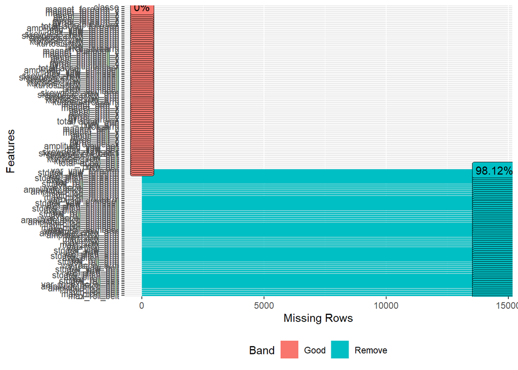

```r
library(Rcpp)
library(DataExplorer)
plot_missing(training)
```

Lots of the columns are 98% NA, these need to be removed before fitting the models.

## View missing

Set the missings to NA and remove the columns with NAs. View the missings again.

```r
training[training==""]<-NA # set missings to NA
trainingClean<-training[,colSums(is.na(training))==0] # remove columns with NAs
dim(trainingClean)
```

```
## [1] 14718    53
```

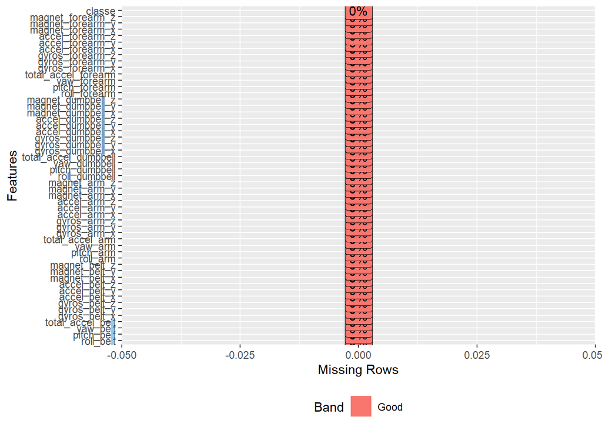

```r
plot_missing(trainingClean)
```

All of the variables are now showing as good.

## Try modelling again

Set 3 fold cross-validation in the control. We are going to test 4 models: Random Forest, GBM, Classification Tree and LDA.

```r
control <- trainControl(method="cv", number=3)
fitRf <- train(classe ~ ., data=trainingClean,trControl=control, method="rf",verbose=FALSE)
fitCT<-train(classe~.,data=trainingClean,method="rpart",trControl=control)
fitGbm <- train(classe ~ ., data=trainingClean,trControl=control, method="gbm",verbose=FALSE)
fitLda <- train(classe ~ ., data=trainingClean,trControl=control, method="lda")
```

The models have now been created without error.

## Apply the predictions on the training dataset and get accuracy figures.

```r
predRftrain<-predict(fitRf,trainingClean)
print(paste0("RF accuracy=",confusionMatrix(predRftrain,trainingClean$classe)$overall['Accuracy']))
```

```
## [1] "RF accuracy=1"
```

```r
confusionMatrix(predRftrain,trainingClean$classe)$table
```

```
##           Reference
## Prediction    A    B    C    D    E
##          A 4185    0    0    0    0
##          B    0 2848    0    0    0
##          C    0    0 2567    0    0
##          D    0    0    0 2412    0
##          E    0    0    0    0 2706
```

```r
predCTtrain<-predict(fitCT,trainingClean)
print(paste0("CT accuracy=",confusionMatrix(predCTtrain,trainingClean$classe)$overall['Accuracy']))
```

```
## [1] "CT accuracy=0.496874575349912"
```

```r
confusionMatrix(predCTtrain,trainingClean$classe)$table
```

```
##           Reference
## Prediction    A    B    C    D    E
##          A 3832 1205 1190 1074  396
##          B   57  953   82  431  352
##          C  286  690 1295  907  725
##          D    0    0    0    0    0
##          E   10    0    0    0 1233
```

```r
predGbmtrain<-predict(fitGbm,trainingClean)
print(paste0("GBM accuracy=",confusionMatrix(predGbmtrain,trainingClean$classe)$overall['Accuracy']))
```

```
## [1] "GBM accuracy=0.972958282375323"
```

```r
confusionMatrix(predGbmtrain,trainingClean$classe)$table
```

```
##           Reference
## Prediction    A    B    C    D    E
##          A 4143   63    0    1    2
##          B   33 2728   56    2   14
##          C    6   56 2485   74   15
##          D    2    1   21 2326   37
##          E    1    0    5    9 2638
```

```r
predLdatrain<-predict(fitLda,trainingClean)
print(paste0("LDA accuracy=",confusionMatrix(predLdatrain,trainingClean$classe)$overall['Accuracy']))
```

```
## [1] "LDA accuracy=0.707365131131947"
```

```r
confusionMatrix(predLdatrain,trainingClean$classe)$table
```

```
##           Reference
## Prediction    A    B    C    D    E
##          A 3433  447  251  139  107
##          B   87 1821  237  101  440
##          C  336  332 1719  277  252
##          D  313  110  288 1796  265
##          E   16  138   72   99 1642
```

## We need to clean the test and validation datasets prior to applying the models.

```r
testing[testing==""]<-NA
testingClean<-testing[,colSums(is.na(testing))==0]
dim(testingClean)
```

```
## [1] 4904   53
```

```r
validation[validation==""]<-NA
validationClean<-validation[,colSums(is.na(validation))==0]
dim(validationClean)
```

```
## [1] 20 53
```

## Predictions for the cleaned test dataset:

```r
predRftest<-predict(fitRf,testingClean)
print(paste0("RF accuracy=",confusionMatrix(predRftest,testingClean$classe)$overall['Accuracy']))
```

```
## [1] "RF accuracy=0.994494290375204"
```

```r
confusionMatrix(predRftest,testingClean$classe)$table
```

```
##           Reference
## Prediction    A    B    C    D    E
##          A 1394    2    0    0    0
##          B    1  944    2    0    0
##          C    0    3  852   11    1
##          D    0    0    1  793    6
##          E    0    0    0    0  894
```

```r
predCTtest<-predict(fitCT,testingClean)
print(paste0("CT accuracy=",confusionMatrix(predCTtest,testingClean$classe)$overall['Accuracy']))
```

```
## [1] "CT accuracy=0.491639477977162"
```

```r
confusionMatrix(predCTtest,testingClean$classe)$table
```

```
##           Reference
## Prediction    A    B    C    D    E
##          A 1254  392  403  382  128
##          B   24  333   26  137  134
##          C  113  224  426  285  241
##          D    0    0    0    0    0
##          E    4    0    0    0  398
```

```r
predGbmtest<-predict(fitGbm,testingClean)
print(paste0("GBM accuracy=",confusionMatrix(predGbmtest,testingClean$classe)$overall['Accuracy']))
```

```
## [1] "GBM accuracy=0.959013050570963"
```

```r
confusionMatrix(predGbmtest,testingClean$classe)$table
```

```
##           Reference
## Prediction    A    B    C    D    E
##          A 1365   23    0    0    2
##          B   24  894   27    3   11
##          C    3   30  818   29    8
##          D    2    1    9  766   20
##          E    1    1    1    6  860
```

```r
predLdatest<-predict(fitLda,testingClean)
print(paste0("LDA accuracy=",confusionMatrix(predLdatest,testingClean$classe)$overall['Accuracy']))
```

```
## [1] "LDA accuracy=0.694535073409462"
```

```r
confusionMatrix(predLdatest,testingClean$classe)$table
```

```
##           Reference
## Prediction    A    B    C    D    E
##          A 1131  130   85   52   24
##          B   36  593   68   29  157
##          C  115  135  558  106   89
##          D  105   47  124  585   92
##          E    8   44   20   32  539
```

The Random Forest model has the highest accuracy at 99%. The accuracy is sufficiently high that model stacking is unlikely to add much benefit.

## Generate the final predictions for the validation data:

```r
predRfvalid<-predict(fitRf,validationClean)
predRfvalid
```

```
##  [1] B A B A A E D B A A B C B A E E A B B B
## Levels: A B C D E
```